# Thera_Bank Project_Final

### Background & Context

Thera bank recently saw a steep decline in the number of users of their credit card, credit cards are a good source of income for banks because of different kinds of fees charged by the banks like annual fees, balance transfer fees, and cash advance fees, late payment fees, foreign transaction fees, and others. Some fees are charged to every user irrespective of usage, while others are charged under specified circumstances.

Customers’ leaving credit cards services would lead bank to loss, so the bank wants to analyze the data of customers and identify the customers who will leave their credit card services and reason for same – so that bank could improve upon those areas

As a Data scientist at Thera bank, my team is charged with the responsibility of building a classification model that will help the bank improve their services so that customers do not renounce their credit cards.

### Objective

- To explore and visualize the dataset.
- Build a classification model to predict if the customer is going to churn or not
- Optimize the model using appropriate techniques
- Generate a set of insights and recommendations that will help the bank

### Data Dictionary

- CLIENTNUM: Client number. Unique identifier for the customer holding the account
- Attrition_Flag: Internal event (customer activity) variable - if the account is closed then "Attrited Customer" else "Existing Customer"
- Customer_Age: Age in Years
- Gender: Gender of the account holder
- Dependent_count: Number of dependents
- Education_Level: Educational Qualification of the account holder - Graduate, High School, Unknown, Uneducated, College(refers to a college student), Post-Graduate, Doctorate
- Marital_Status: Marital Status of the account holder
- Income_Category: Annual Income Category of the account holder
- Card_Category: Type of Card
- Months_on_book: Period of relationship with the bank
- Total_Relationship_Count: Total no. of products held by the customer
- Months_Inactive_12_mon: No. of months inactive in the last 12 months
- Contacts_Count_12_mon: No. of Contacts between the customer and bank in the last 12 months
- Credit_Limit: Credit Limit on the Credit Card
- Total_Revolving_Bal: The balance that carries over from one month to the next is the revolving balance
- Avg_Open_To_Buy: Open to Buy refers to the amount left on the credit card to use (Average of last 12 months)
- Total_Trans_Amt: Total Transaction Amount (Last 12 months)
- Total_Trans_Ct: Total Transaction Count (Last 12 months)
- Total_Ct_Chng_Q4_Q1: Ratio of the total transaction count in 4th quarter and the total transaction count in 1st quarter
- Total_Amt_Chng_Q4_Q1: Ratio of the total transaction amount in 4th quarter and the total transaction amount in 1st quarter
- Avg_Utilization_Ratio: Represents how much of the available credit the customer spent

### Index

- Overview of the dataset
- Exploratory Data Analysis(EDA)
- Customer Level Analysis by Card Category
- Outlier Treatment
- Model Building
- Feature Engineering
- Split Data
- Logistic Regression Model
- Bagging Models
- Boosting Models
- HyperParameter Tuning
- Model Performance Comparison
- Business Recommendations

## Overview of Dataset

### Import necessary Libraries

```python
# Packages to Read and Manipulate Data
import numpy as np
import pandas as pd

# Packages  enabling Exploratory Data Visualization
import matplotlib.pyplot as plt
import seaborn as sns

# Packages for  Building Models
from sklearn.tree import DecisionTreeClassifier
from sklearn import tree
from sklearn.ensemble import BaggingClassifier
from sklearn.ensemble import RandomForestClassifier
from sklearn.ensemble import AdaBoostClassifier, GradientBoostingClassifier
from xgboost import XGBClassifier
from sklearn.linear_model import LogisticRegression

# Model tuning, Data Split and Metric Scores
from sklearn.preprocessing import StandardScaler
from sklearn.pipeline import Pipeline, make_pipeline
from sklearn.model_selection import GridSearchCV
from sklearn.model_selection import RandomizedSearchCV
from sklearn.model_selection import train_test_split, StratifiedKFold, cross_val_score
from sklearn.metrics import confusion_matrix, classification_report
from sklearn.metrics import accuracy_score,precision_score,recall_score,f1_score
import scipy.stats as stats
from sklearn import metrics

# To impute missing values if any
from sklearn.impute import KNNImputer

# To Suppress Warnings
import warnings
warnings.filterwarnings('ignore')
```

### Read the dataset

```python
cr_data = pd.read_csv("BankChurners.csv")
```

```python
# copying data to another variable to avoid any changes to original data
df=cr_data.copy()
```

### View the first and last 5 rows of the dataset.

```python
df.head()
```

|  | CLIENTNUM | Attrition_Flag | Customer_Age | Gender | Dependent_count | Education_Level | Marital_Status | Income_Category | Card_Category | Months_on_book | ... | Months_Inactive_12_mon | Contacts_Count_12_mon | Credit_Limit | Total_Revolving_Bal | Avg_Open_To_Buy | Total_Amt_Chng_Q4_Q1 | Total_Trans_Amt | Total_Trans_Ct | Total_Ct_Chng_Q4_Q1 | Avg_Utilization_Ratio |
| --- | --- | --- | --- | --- | --- | --- | --- | --- | --- | --- | --- | --- | --- | --- | --- | --- | --- | --- | --- | --- | --- |
| 0 | 768805383 | Existing Customer | 45 | M | 3 | High School | Married | $60K - $80K | Blue | 39 | ... | 1 | 3 | 12691.0 | 777 | 11914.0 | 1.335 | 1144 | 42 | 1.625 | 0.061 |
| 1 | 818770008 | Existing Customer | 49 | F | 5 | Graduate | Single | Less than $40K | Blue | 44 | ... | 1 | 2 | 8256.0 | 864 | 7392.0 | 1.541 | 1291 | 33 | 3.714 | 0.105 |
| 2 | 713982108 | Existing Customer | 51 | M | 3 | Graduate | Married | $80K - $120K | Blue | 36 | ... | 1 | 0 | 3418.0 | 0 | 3418.0 | 2.594 | 1887 | 20 | 2.333 | 0.000 |
| 3 | 769911858 | Existing Customer | 40 | F | 4 | High School | Unknown | Less than $40K | Blue | 34 | ... | 4 | 1 | 3313.0 | 2517 | 796.0 | 1.405 | 1171 | 20 | 2.333 | 0.760 |
| 4 | 709106358 | Existing Customer | 40 | M | 3 | Uneducated | Married | $60K - $80K | Blue | 21 | ... | 1 | 0 | 4716.0 | 0 | 4716.0 | 2.175 | 816 | 28 | 2.500 | 0.000 |

5 rows × 21 columns

```python
df.tail()
```

|  | CLIENTNUM | Attrition_Flag | Customer_Age | Gender | Dependent_count | Education_Level | Marital_Status | Income_Category | Card_Category | Months_on_book | ... | Months_Inactive_12_mon | Contacts_Count_12_mon | Credit_Limit | Total_Revolving_Bal | Avg_Open_To_Buy | Total_Amt_Chng_Q4_Q1 | Total_Trans_Amt | Total_Trans_Ct | Total_Ct_Chng_Q4_Q1 | Avg_Utilization_Ratio |
| --- | --- | --- | --- | --- | --- | --- | --- | --- | --- | --- | --- | --- | --- | --- | --- | --- | --- | --- | --- | --- | --- |
| 10122 | 772366833 | Existing Customer | 50 | M | 2 | Graduate | Single | $40K - $60K | Blue | 40 | ... | 2 | 3 | 4003.0 | 1851 | 2152.0 | 0.703 | 15476 | 117 | 0.857 | 0.462 |
| 10123 | 710638233 | Attrited Customer | 41 | M | 2 | Unknown | Divorced | $40K - $60K | Blue | 25 | ... | 2 | 3 | 4277.0 | 2186 | 2091.0 | 0.804 | 8764 | 69 | 0.683 | 0.511 |
| 10124 | 716506083 | Attrited Customer | 44 | F | 1 | High School | Married | Less than $40K | Blue | 36 | ... | 3 | 4 | 5409.0 | 0 | 5409.0 | 0.819 | 10291 | 60 | 0.818 | 0.000 |
| 10125 | 717406983 | Attrited Customer | 30 | M | 2 | Graduate | Unknown | $40K - $60K | Blue | 36 | ... | 3 | 3 | 5281.0 | 0 | 5281.0 | 0.535 | 8395 | 62 | 0.722 | 0.000 |
| 10126 | 714337233 | Attrited Customer | 43 | F | 2 | Graduate | Married | Less than $40K | Silver | 25 | ... | 2 | 4 | 10388.0 | 1961 | 8427.0 | 0.703 | 10294 | 61 | 0.649 | 0.189 |

5 rows × 21 columns

### Understand the shape of the dataset.

```python
df.shape
```

```
(10127, 21)
```

- The dataset has 10127 rows and 21 columns of data

### Check the data types of the columns for the dataset.

```python
df.dtypes
```

```
CLIENTNUM                     int64
Attrition_Flag               object
Customer_Age                  int64
Gender                       object
Dependent_count               int64
Education_Level              object
Marital_Status               object
Income_Category              object
Card_Category                object
Months_on_book                int64
Total_Relationship_Count      int64
Months_Inactive_12_mon        int64
Contacts_Count_12_mon         int64
Credit_Limit                float64
Total_Revolving_Bal           int64
Avg_Open_To_Buy             float64
Total_Amt_Chng_Q4_Q1        float64
Total_Trans_Amt               int64
Total_Trans_Ct                int64
Total_Ct_Chng_Q4_Q1         float64
Avg_Utilization_Ratio       float64
dtype: object
```

**Observations -**

- We can convert the object type columns to categories to free up more memory space.
- Also note that Attrition_Flag,Gender,Education_Level,Marital_Status,Income_Category and Card_Category will all equally be converted to category.
- Note also that our Target variable being, Attrition_Flag, will be modified to a class variable utlimately prior to modelling

`converting "objects" to "category" reduces the data space required to store the dataframe`

### Fixing the data types

```python
cols = df.select_dtypes(['object'])
cols.columns
```

```
Index(['Attrition_Flag', 'Gender', 'Education_Level', 'Marital_Status',
       'Income_Category', 'Card_Category'],
      dtype='object')
```

```python
for i in cols.columns:
    df[i] = df[i].astype('category')
```

```python
df.dtypes # to establish conversion
```

```
CLIENTNUM                      int64
Attrition_Flag              category
Customer_Age                   int64
Gender                      category
Dependent_count                int64
Education_Level             category
Marital_Status              category
Income_Category             category
Card_Category               category
Months_on_book                 int64
Total_Relationship_Count       int64
Months_Inactive_12_mon         int64
Contacts_Count_12_mon          int64
Credit_Limit                 float64
Total_Revolving_Bal            int64
Avg_Open_To_Buy              float64
Total_Amt_Chng_Q4_Q1         float64
Total_Trans_Amt                int64
Total_Trans_Ct                 int64
Total_Ct_Chng_Q4_Q1          float64
Avg_Utilization_Ratio        float64
dtype: object
```

```python
df.Attrition_Flag.value_counts() # To confirm the balance in the dataset by variable of interest.
```

```
Existing Customer    8500
Attrited Customer    1627
Name: Attrition_Flag, dtype: int64
```

- We can see there is an imbalance in the dataset. We will have to establish the ratio and handle this prior to modelling

```python
df.drop('CLIENTNUM', inplace=True, axis=1) # Dropping the Client Number as it is of no significane in our analysis
```

```python
df.sample(10)
```

|  | Attrition_Flag | Customer_Age | Gender | Dependent_count | Education_Level | Marital_Status | Income_Category | Card_Category | Months_on_book | Total_Relationship_Count | Months_Inactive_12_mon | Contacts_Count_12_mon | Credit_Limit | Total_Revolving_Bal | Avg_Open_To_Buy | Total_Amt_Chng_Q4_Q1 | Total_Trans_Amt | Total_Trans_Ct | Total_Ct_Chng_Q4_Q1 | Avg_Utilization_Ratio |
| --- | --- | --- | --- | --- | --- | --- | --- | --- | --- | --- | --- | --- | --- | --- | --- | --- | --- | --- | --- | --- |
| 483 | Existing Customer | 46 | F | 4 | Post-Graduate | Married | Less than $40K | Blue | 37 | 5 | 3 | 2 | 3773.0 | 1972 | 1801.0 | 0.783 | 1528 | 25 | 1.083 | 0.523 |
| 8760 | Existing Customer | 49 | M | 2 | Graduate | Married | $80K - $120K | Silver | 39 | 1 | 1 | 2 | 34516.0 | 1118 | 33398.0 | 0.671 | 7734 | 74 | 0.609 | 0.032 |
| 5068 | Existing Customer | 48 | M | 3 | Unknown | Married | $120K + | Blue | 43 | 5 | 3 | 0 | 6626.0 | 1558 | 5068.0 | 1.020 | 2838 | 49 | 1.333 | 0.235 |
| 8772 | Existing Customer | 51 | F | 5 | High School | Single | Less than $40K | Blue | 36 | 1 | 1 | 1 | 7645.0 | 2076 | 5569.0 | 0.759 | 7710 | 75 | 0.875 | 0.272 |
| 5996 | Existing Customer | 47 | F | 3 | Graduate | Married | Less than $40K | Blue | 36 | 3 | 1 | 2 | 3147.0 | 2453 | 694.0 | 0.744 | 4465 | 82 | 0.952 | 0.779 |
| 5140 | Existing Customer | 46 | F | 3 | Uneducated | Married | $40K - $60K | Blue | 36 | 6 | 3 | 2 | 13387.0 | 0 | 13387.0 | 0.746 | 3706 | 81 | 0.620 | 0.000 |
| 9506 | Existing Customer | 43 | M | 2 | High School | Married | $60K - $80K | Blue | 31 | 2 | 3 | 1 | 13381.0 | 1845 | 11536.0 | 0.883 | 14532 | 116 | 0.871 | 0.138 |
| 7714 | Existing Customer | 42 | F | 2 | Uneducated | Married | Unknown | Blue | 32 | 5 | 5 | 3 | 4708.0 | 0 | 4708.0 | 0.718 | 4597 | 89 | 0.679 | 0.000 |
| 7854 | Existing Customer | 61 | M | 0 | Graduate | Married | Unknown | Blue | 36 | 2 | 3 | 3 | 6959.0 | 945 | 6014.0 | 0.816 | 4553 | 84 | 0.714 | 0.136 |
| 1271 | Existing Customer | 32 | F | 0 | High School | Divorced | Less than $40K | Blue | 36 | 5 | 2 | 4 | 2699.0 | 1609 | 1090.0 | 0.893 | 2141 | 56 | 0.806 | 0.596 |

### Check Missing Values in Dataset

```python
df.isnull().sum()
```

```
Attrition_Flag              0
Customer_Age                0
Gender                      0
Dependent_count             0
Education_Level             0
Marital_Status              0
Income_Category             0
Card_Category               0
Months_on_book              0
Total_Relationship_Count    0
Months_Inactive_12_mon      0
Contacts_Count_12_mon       0
Credit_Limit                0
Total_Revolving_Bal         0
Avg_Open_To_Buy             0
Total_Amt_Chng_Q4_Q1        0
Total_Trans_Amt             0
Total_Trans_Ct              0
Total_Ct_Chng_Q4_Q1         0
Avg_Utilization_Ratio       0
dtype: int64
```

- There are no missing values in the dataset

### Summary of the dataset

```python
df.describe().T
```

|  | count | mean | std | min | 25% | 50% | 75% | max |
| --- | --- | --- | --- | --- | --- | --- | --- | --- |
| Customer_Age | 10127.0 | 46.325960 | 8.016814 | 26.0 | 41.000 | 46.000 | 52.000 | 73.000 |
| Dependent_count | 10127.0 | 2.346203 | 1.298908 | 0.0 | 1.000 | 2.000 | 3.000 | 5.000 |
| Months_on_book | 10127.0 | 35.928409 | 7.986416 | 13.0 | 31.000 | 36.000 | 40.000 | 56.000 |
| Total_Relationship_Count | 10127.0 | 3.812580 | 1.554408 | 1.0 | 3.000 | 4.000 | 5.000 | 6.000 |
| Months_Inactive_12_mon | 10127.0 | 2.341167 | 1.010622 | 0.0 | 2.000 | 2.000 | 3.000 | 6.000 |
| Contacts_Count_12_mon | 10127.0 | 2.455317 | 1.106225 | 0.0 | 2.000 | 2.000 | 3.000 | 6.000 |
| Credit_Limit | 10127.0 | 8631.953698 | 9088.776650 | 1438.3 | 2555.000 | 4549.000 | 11067.500 | 34516.000 |
| Total_Revolving_Bal | 10127.0 | 1162.814061 | 814.987335 | 0.0 | 359.000 | 1276.000 | 1784.000 | 2517.000 |
| Avg_Open_To_Buy | 10127.0 | 7469.139637 | 9090.685324 | 3.0 | 1324.500 | 3474.000 | 9859.000 | 34516.000 |
| Total_Amt_Chng_Q4_Q1 | 10127.0 | 0.759941 | 0.219207 | 0.0 | 0.631 | 0.736 | 0.859 | 3.397 |
| Total_Trans_Amt | 10127.0 | 4404.086304 | 3397.129254 | 510.0 | 2155.500 | 3899.000 | 4741.000 | 18484.000 |
| Total_Trans_Ct | 10127.0 | 64.858695 | 23.472570 | 10.0 | 45.000 | 67.000 | 81.000 | 139.000 |
| Total_Ct_Chng_Q4_Q1 | 10127.0 | 0.712222 | 0.238086 | 0.0 | 0.582 | 0.702 | 0.818 | 3.714 |
| Avg_Utilization_Ratio | 10127.0 | 0.274894 | 0.275691 | 0.0 | 0.023 | 0.176 | 0.503 | 0.999 |

### Observations

```python
df.describe(include=['category']).T
```

|  | count | unique | top | freq |
| --- | --- | --- | --- | --- |
| Attrition_Flag | 10127 | 2 | Existing Customer | 8500 |
| Gender | 10127 | 2 | F | 5358 |
| Education_Level | 10127 | 7 | Graduate | 3128 |
| Marital_Status | 10127 | 4 | Married | 4687 |
| Income_Category | 10127 | 6 | Less than $40K | 3561 |
| Card_Category | 10127 | 4 | Blue | 9436 |

### Observation

- 8500 of Thera Bank customers who are Existing customers in the Bank's books are the most in the distribution
- Majority of the customers (5358) are females.
- Graduate Education level customers is the most in acrross the distribution
- Married customers have the highest number in the distribution at 4687
- 3561 Customers who earn less than $40k per annum trumps tcounterparts in other categories
- 9436 Blue credit cards secure the top spot ahead of other card types among customers of the bank

**Let's look at the unqiue values of all the categories**

```python
cols_cat= df.select_dtypes(['category'])
```

```python
for i in cols_cat.columns:
    print('Unique values in',i, 'are :')
    print(cols_cat[i].value_counts())
    print('*'*50)
```

```
Unique values in Attrition_Flag are :
Existing Customer    8500
Attrited Customer    1627
Name: Attrition_Flag, dtype: int64
Unique values in Gender are :
F    5358
M    4769
Name: Gender, dtype: int64
Unique values in Education_Level are :
Graduate         3128
High School      2013
Unknown          1519
Uneducated       1487
College          1013
Post-Graduate     516
Doctorate         451
Name: Education_Level, dtype: int64
Unique values in Marital_Status are :
Married     4687
Single      3943
Unknown      749
Divorced     748
Name: Marital_Status, dtype: int64
Unique values in Income_Category are :
Less than $40K    3561
$40K - $60K       1790
$80K - $120K      1535
$60K - $80K       1402
Unknown           1112
$120K +            727
Name: Income_Category, dtype: int64
Unique values in Card_Category are :
Blue        9436
Silver       555
Gold         116
Platinum      20
Name: Card_Category, dtype: int64
```

- There are 8500 Existing customers constituting majority of Thera customers
- There are 5358 Females in majority across Genders
- 3128 Graduates trump the rest of their counterparts under Education_Level with 451 Doctorates as the least
- 4687 customers are married and are in majority under Marital Status
- There are 3561 customers who earn less than $40k and by far trumps the rest of thhe category
- Blue credit card holders have the highest subscription in the customer distribution

### Exploratory Data Analysis ( EDA)

### Univariate analysis

```python
# While doing uni-variate analysis of numerical variables we want to study their central tendency
# and dispersion.
# Let us write a function that will help us create boxplot and histogram for any input numerical
# variable.
# This function takes the numerical column as the input and returns the boxplots
# and histograms for the variable.
# Let us see if this help us write faster and cleaner code.
def histogram_boxplot(feature, figsize=(15,10), bins = None):
    """ Boxplot and histogram combined
    feature: 1-d feature array
    figsize: size of fig (default (9,8))
    bins: number of bins (default None / auto)
    """
    f2, (ax_box2, ax_hist2) = plt.subplots(nrows = 2, # Number of rows of the subplot grid= 2
                                           sharex = True, # x-axis will be shared among all subplots
                                           gridspec_kw = {"height_ratios": (.25, .75)},
                                           figsize = figsize
                                           ) # creating the 2 subplots
    sns.boxplot(feature, ax=ax_box2, showmeans=True, color='violet') # boxplot will be created and a star will indicate the mean value of the column
    sns.distplot(feature, kde=F, ax=ax_hist2, bins=bins,palette="winter") if bins else sns.distplot(feature, kde=False, ax=ax_hist2) # For histogram
    ax_hist2.axvline(np.mean(feature), color='green', linestyle='--') # Add mean to the histogram
    ax_hist2.axvline(np.median(feature), color='black', linestyle='-') # Add median to the histogram
```

### Observations on Customer_Age

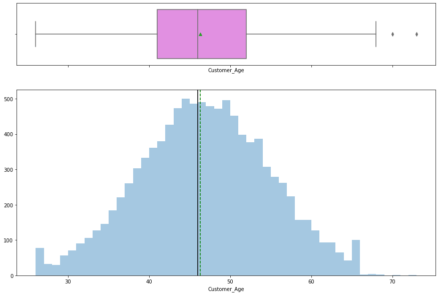

```python
histogram_boxplot(df['Customer_Age'])
plt.savefig('Plt_Age.png')
plt.show()
```

### Observations on Dependent_count

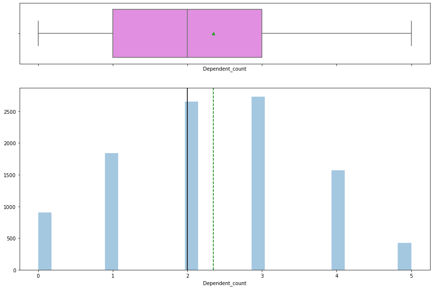

```python
histogram_boxplot(df['Dependent_count'])
plt.savefig('Plt_Dep_C.png')
plt.show()
```

### Observations on Months_on_book

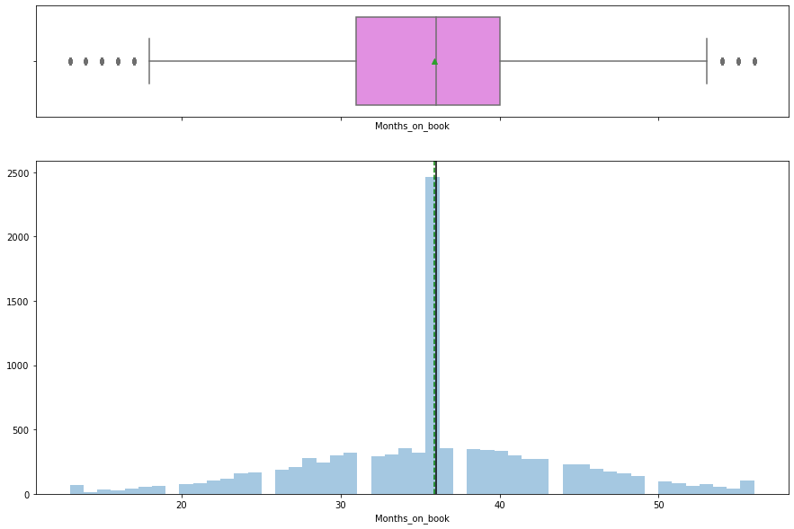

```python
histogram_boxplot(df['Months_on_book'])
plt.savefig('Plt_MoB.png')
plt.show()
```

- Thera Bank has customers who have stayed approx. 36 months on average in their books with 75% of them having stayed 40 months or less
- This clearly indicates that majority of the customers have banked for a while with Thera .
- The highest in their books comes in at 56 months. Clear presence of outliers.

### Observations on Total_Relationship_count

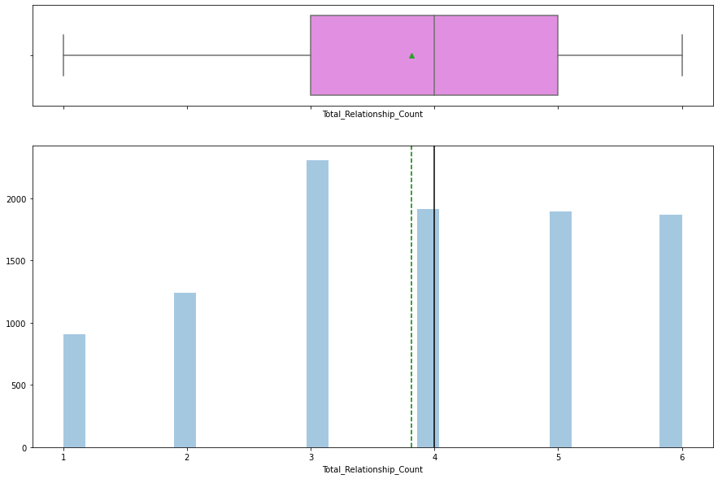

```python
histogram_boxplot(df['Total_Relationship_Count'])
plt.savefig('Plt_TRc.png')
plt.show()
```

- The Mean number products held by Thera Bank customers are approx. 4 with the highest at 6.
- 75% of the distribution maintains at least 5 products or less with the Bank
- There are no presence of outliers

### Observations on Months_Inactive_12_mon

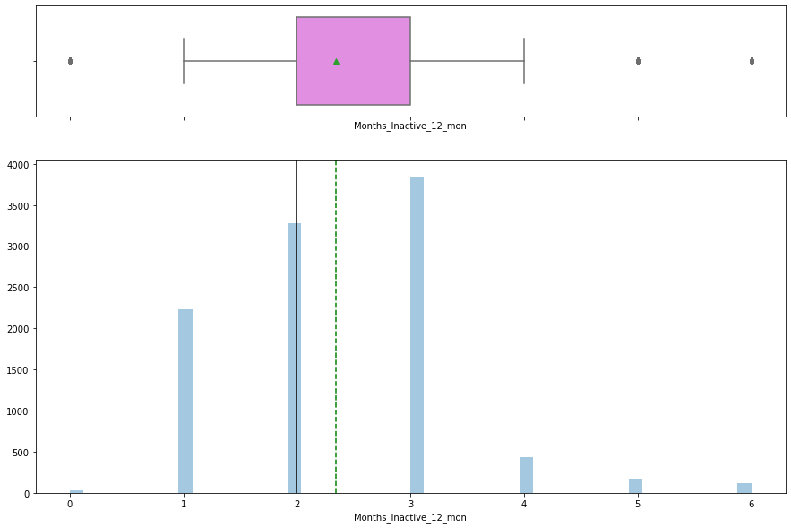

```python
histogram_boxplot(df['Months_Inactive_12_mon'])
plt.savefig('Plt_MIY.png')
plt.show()
```

- 75% of the customers were inactive for 3 months or less within 12 monhs of card subscription
- There are presence of outliers peaking at around 0, 5 and 6 months respectively.
- The distribution is right skewed. Mean is greater than Median

### Observations on Contacts_Count_12_mon

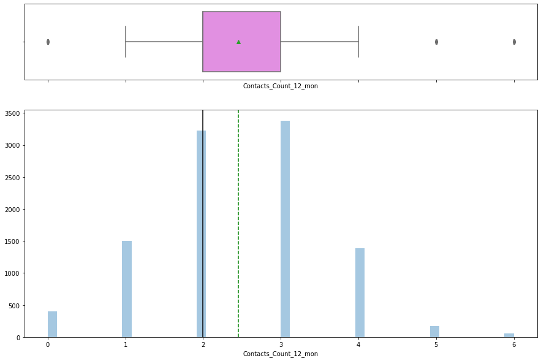

```python
histogram_boxplot(df['Contacts_Count_12_mon'])
plt.savefig('Plt_CCY.png')
plt.show()
```

- We can infer that the average customer contact accross the distribution is 2 in a year. The other 3 peaks are at 1 ,3 and 4
- We can also see that customers that were never contacted and those contacted 5 or more times account for the outliers here
- How this influences customer retention or credit card churn would be established